# Normalization vol. 2

Kacper Kaszuba

2024-09-19

# Load Data

```r
lfq <- read.csv('./data/LFQ_raw_totals_imp.csv')
knitr::kable(head(lfq), format='html')
```

| KO_TOTALS_22 | KO_TOTALS_23 | KO_TOTALS_24 | WT_TOTALS_22 | WT_TOTALS_23 | WT_TOTALS_24 |
| --- | --- | --- | --- | --- | --- |
| 22.44817 | 22.44805 | 23.05376 | 22.45849 | 22.39561 | 22.39090 |
| 22.24563 | 22.24258 | 22.86036 | 22.25553 | 22.18766 | 22.18389 |
| 20.06529 | 20.03072 | 20.77835 | 20.07056 | 19.94892 | 19.95532 |
| 21.54988 | 21.53677 | 22.19598 | 21.55829 | 21.47326 | 21.47274 |
| 21.92025 | 21.91249 | 23.19647 | 21.92945 | 22.00220 | 21.85130 |
| 23.88101 | 23.58256 | 26.41355 | 24.20970 | 23.28630 | 23.16521 |

# Data Preparation

```r
# Extracting only TOTALS data for knockout
LFQ_KO <- lfq %>% select(contains('KO_TOTALS')) #%>% mutate(celltype = 'KO')

# Extracting only TOTALS data for wild type
LFQ_WT <- lfq %>% select(contains('WT_TOTALS')) #%>% mutate(celltype = 'WT')
```

# Data Mining

First of all, we have to check the distribution of our data.

## Knockout

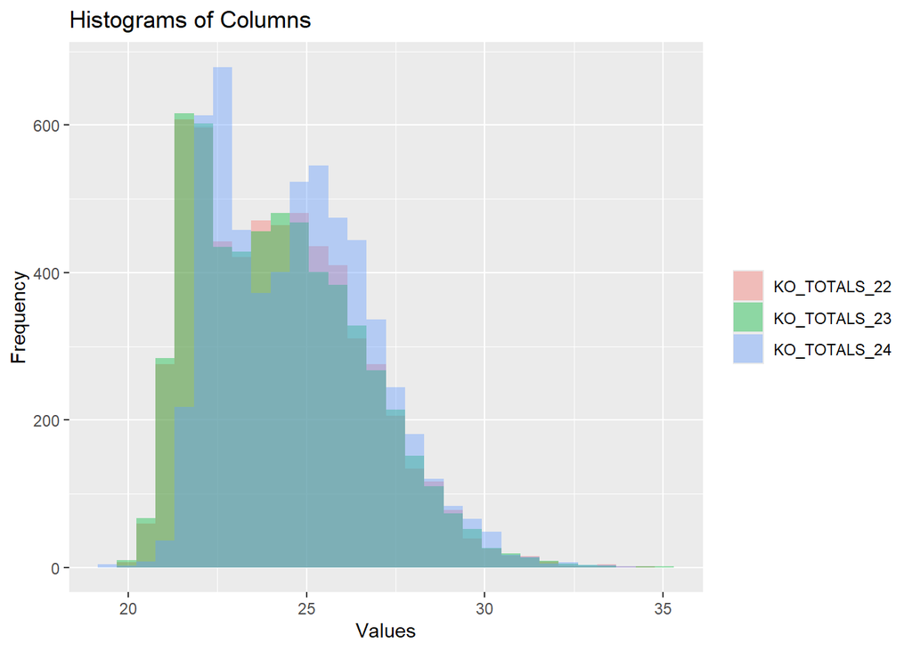

```r
plothist(LFQ_KO)
```

As we see on the historam of konckout columns, the data are slightly skewed to the right.

```r
moments::skewness(LFQ_KO)
```

```
## KO_TOTALS_22 KO_TOTALS_23 KO_TOTALS_24
##    0.5761698    0.5868388    0.5206581
```

The asymmetry score tells use that we need to make some transformation of our data and confirms the conclusions drawn from the histogram.

## Wild type

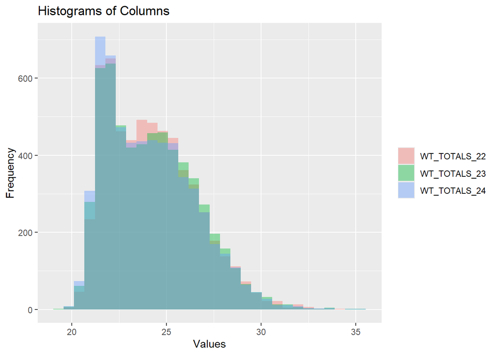

```r
plothist(LFQ_WT)
```

As we see on the historam of wild type columns, the data are slightly skewed to the right.

```r
moments::skewness(LFQ_WT[,1:3])
```

```
## WT_TOTALS_22 WT_TOTALS_23 WT_TOTALS_24
##    0.6285968    0.5813767    0.6579983
```

The asymmetry score tells use that we have to make some transformation of our data and confirms the conclusions drawn from the histogram.

# Transformation - KO

Based on the graphic below, we will first use the natural logarithm.

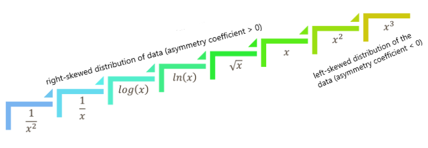

## Logarithm

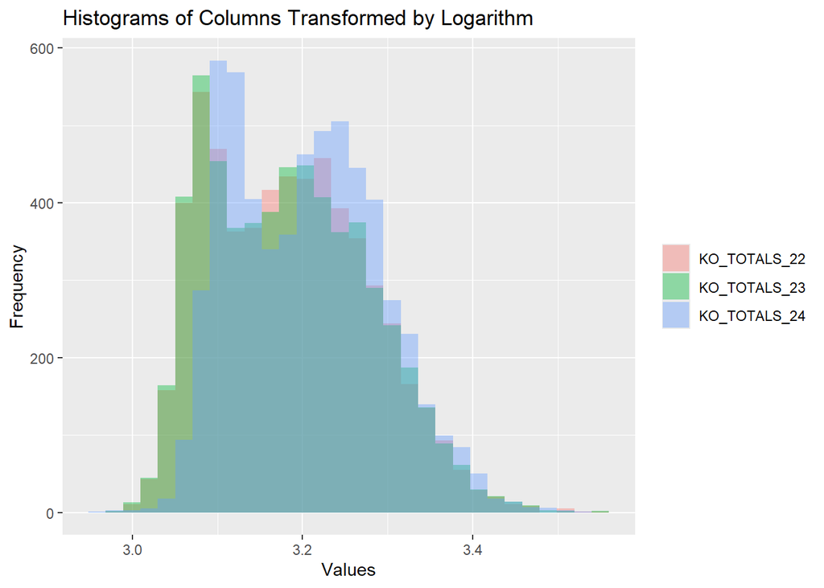

```r
LFQ_KO.log <- log(LFQ_KO)

plothist(LFQ_KO.log, 'Transformed by Logarithm')
```

The data distributions looks better, but they are still skewed to the right side.

```r
moments::skewness(LFQ_KO.log)
```

```
## KO_TOTALS_22 KO_TOTALS_23 KO_TOTALS_24
##    0.3737451    0.3857815    0.3298938
```

The skewness score is smaler. This is good, but check another transformation.

## Fraction $1/x$

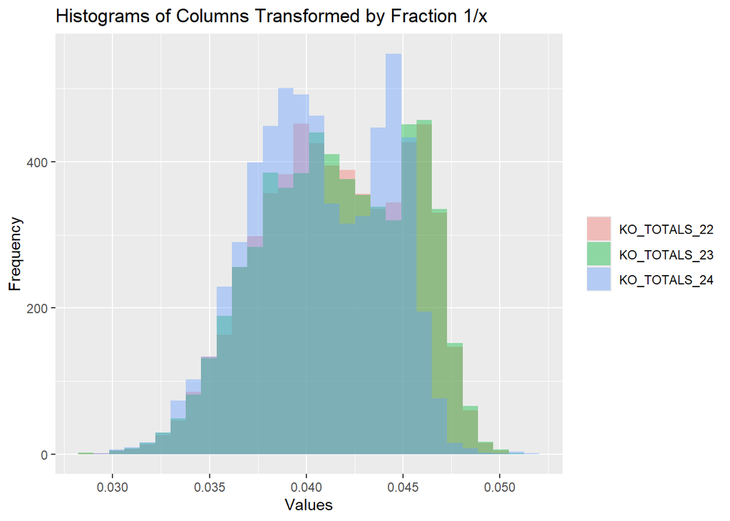

```r
LFQ_KO.frac <- 1/LFQ_KO

plothist(LFQ_KO.frac, 'Transformed by Fraction 1/x')
```

```r
moments::skewness(LFQ_KO.frac)
```

```
## KO_TOTALS_22 KO_TOTALS_23 KO_TOTALS_24
##   -0.1923018   -0.2050843   -0.1563752
```

As we see above the plot and scores of the skewness aren’t close to normal distribution. Our result shows us that with simple transformation we can’t transform data and make their distribution closer to the Gaussian.

## Box-Cos Transformation

The transformation is based on the formula:

$$x' = \Bigg\{
\matrix{\frac{x^{\lambda}-1}{\lambda} & \lambda \neq0 \\
log(x) & \lambda = 0}$$

```r
# At first we have to calculate the lambda
lambda.22 <- car::powerTransform(LFQ_KO$KO_TOTALS_22)$lambda
lambda.23 <- car::powerTransform(LFQ_KO$KO_TOTALS_23)$lambda
lambda.24 <- car::powerTransform(LFQ_KO$KO_TOTALS_24)$lambda
knitr::kable(data.frame(lambda.22, lambda.23, lambda.24, row.names = 'lambda'), format = 'html')
```

|  | lambda.22 | lambda.23 | lambda.24 |
| --- | --- | --- | --- |
| lambda | -1.870607 | -1.929126 | -1.727173 |

The lambda is not 0, so the first transformation is performed.

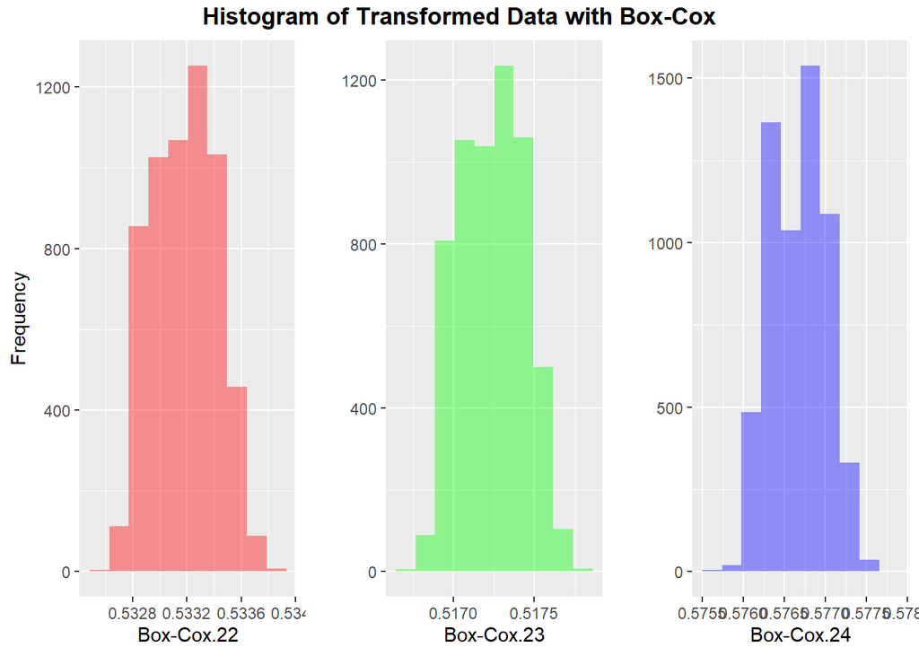

```r
LFQ_KO.boxcox.22 <- car::bcPower(LFQ_KO$KO_TOTALS_22, lambda.22)
LFQ_KO.boxcox.23 <- car::bcPower(LFQ_KO$KO_TOTALS_23, lambda.23)
LFQ_KO.boxcox.24 <- car::bcPower(LFQ_KO$KO_TOTALS_24, lambda.24)
LFQ_KO.boxcox <- data.frame(LFQ_KO.boxcox.22, LFQ_KO.boxcox.23, LFQ_KO.boxcox.24)
colnames(LFQ_KO.boxcox) <- c('KO_TOTALS_22', 'KO_TOTALS_23', 'KO_TOTALS_24')
```

```r
moments::skewness(LFQ_KO.boxcox)
```

```
## KO_TOTALS_22 KO_TOTALS_23 KO_TOTALS_24
##   0.04771938   0.05134458   0.03856700
```

Finally we have got expected results. The distributions are similar to a normal distribution. 🎉

# Normalization - KO

## Z-score Normalization

Z-score normalization standardizes data by subtracting the mean and dividing by the standard deviation. This technique transforms data into a distribution with a mean of 0 and a standard deviation of 1.

Formula: $\tilde{y}_{ij} = \frac{y_ij - \bar{y_j}}{\theta_j}$, where:

- $y_ij$ - value of the LFQ;
- $\bar{y_j}$ - mean of the LFQ values;
- $\theta_j$ - standard deviation of the LFQ values.

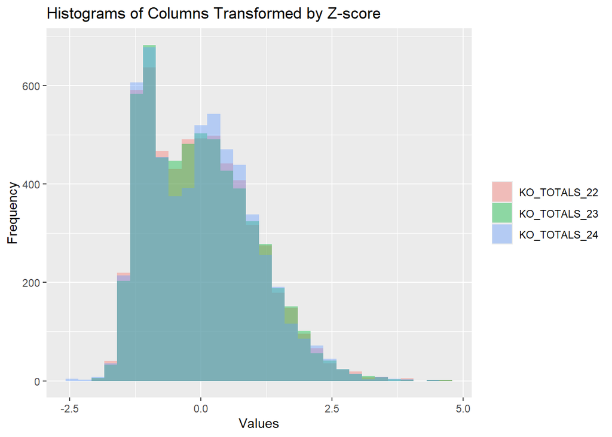

```r
LFQ_KO.standard <- as.data.frame(scale(LFQ_KO))
plothist(LFQ_KO.standard, 'Transformed by Z-score')
```

```r
moments::skewness(LFQ_KO.standard)
```

```
## KO_TOTALS_22 KO_TOTALS_23 KO_TOTALS_24
##    0.5761698    0.5868388    0.5206581
```

Unfortunately the standardization didn’t help to bring the distribution closer to the normal dist.

## Min-max Normalization

Min-max normalization scales data to a specified range (usually [0, 1]) by subtracting the minimum value and dividing by the range of values.

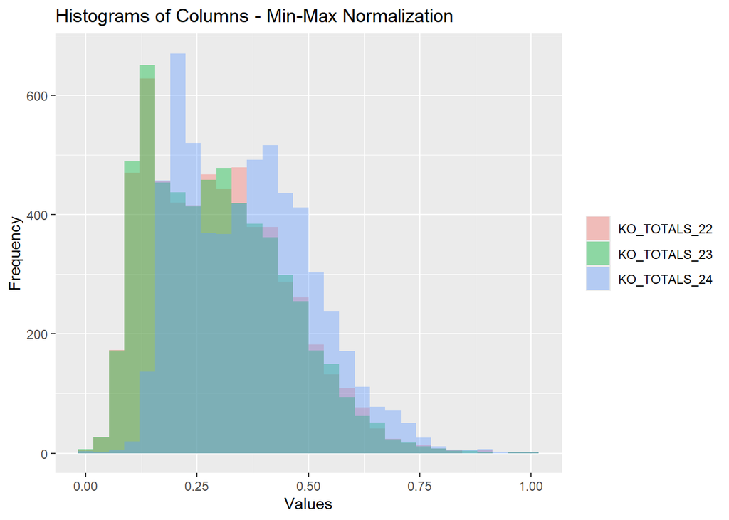

```r
min_max_norm <- function(df) {
    ret <- scale(df, center = min(df), scale = max(df) - min(df))
    return(ret)
}

LFQ_KO.minmax <- as.data.frame(lapply(LFQ_KO, function(col) min_max_norm(col)))
plothist(LFQ_KO.minmax, '- Min-Max Normalization')
```

```r
moments::skewness(LFQ_KO.minmax)
```

```
## KO_TOTALS_22 KO_TOTALS_23 KO_TOTALS_24
##    0.5761698    0.5868388    0.5206581
```

Unfortunately, again the normalization didn’t help. 😒

## Median Scaling

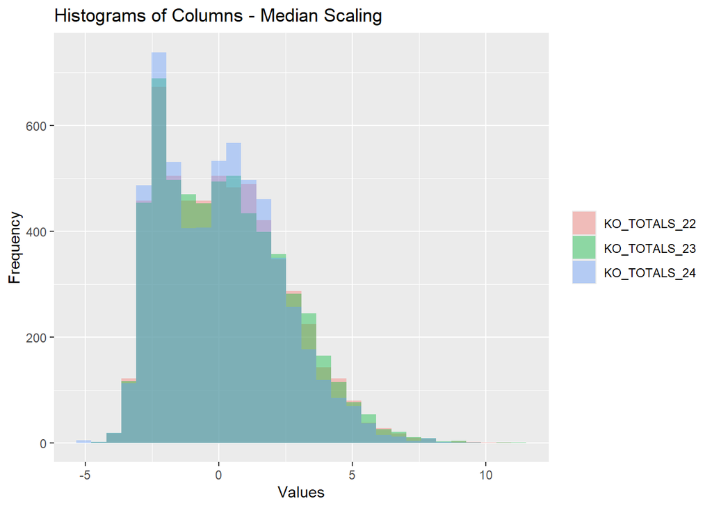

```r
LFQ_KO.med <- as.data.frame(DescTools::RobScale(LFQ_KO, scale = FALSE))
plothist(LFQ_KO.med, '- Median Scaling')
```

```r
moments::skewness(LFQ_KO.med)
```

```
## KO_TOTALS_22 KO_TOTALS_23 KO_TOTALS_24
##    0.5761698    0.5868388    0.5206581
```

## MAD Scaling

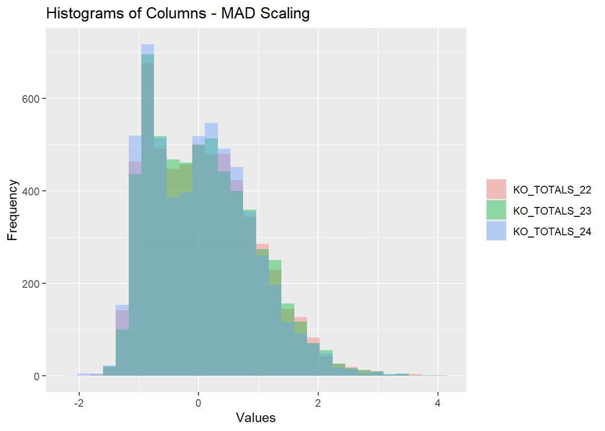

```r
LFQ_KO.mad <- as.data.frame(DescTools::RobScale(LFQ_KO))
plothist(LFQ_KO.mad, '- MAD Scaling')
```

```r
moments::skewness(LFQ_KO.mad)
```

```
## KO_TOTALS_22 KO_TOTALS_23 KO_TOTALS_24
##    0.5761698    0.5868388    0.5206581
```

Bove Median and Mad Scaling didn’t give us the expected result.

## Linear Regression Normalization

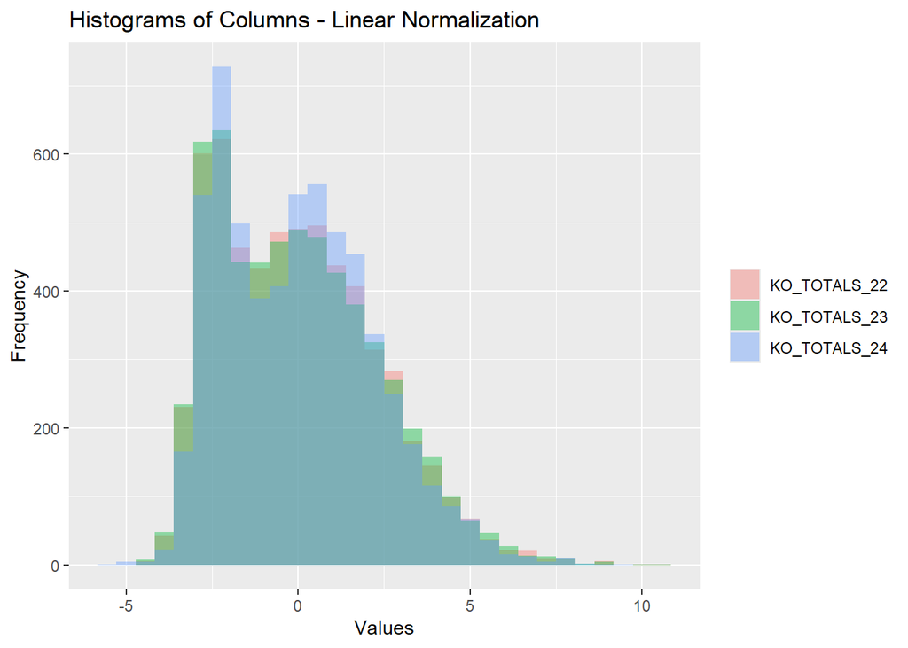

```r
LFQ_KO_long <- LFQ_KO %>%
    pivot_longer(cols = 1:3, names_to = "Rep", values_to = "LFQValue")
    #%>% mutate(celltype = rep(c(rep('KO', 3), rep('WT', 3)), nrow(lfq)))

model <- lm(LFQValue ~ Rep, data=LFQ_KO_long)
LFQ_KO_long$normalized <- residuals(model)

LFQ_KO.lm <- LFQ_KO_long %>%
    mutate(row = rep(1:nrow(LFQ_KO), each=3)) %>%
    reshape2::dcast(row ~ Rep, value.var='normalized') %>%
    select(-row)

plothist(LFQ_KO.lm, '- Linear Normalization')
```

```r
moments::skewness(LFQ_KO.lm)
```

```
## KO_TOTALS_22 KO_TOTALS_23 KO_TOTALS_24
##    0.5761698    0.5868388    0.5206581
```

Linear Regression also didn’t give us expected result.

# Transformation - WT

Like earlier we will first use the logarithmic transformation.

## Logarithm

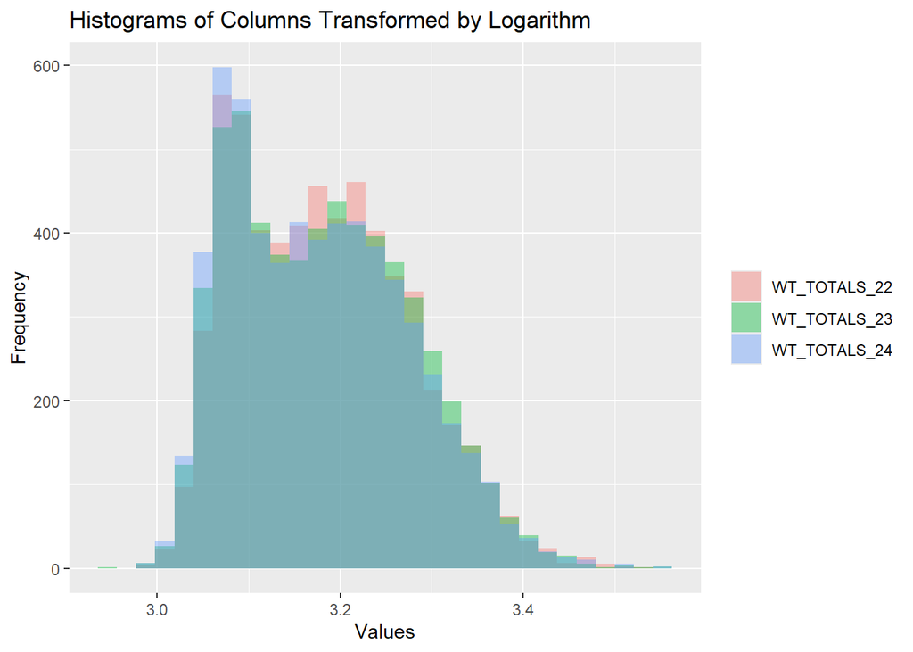

```r
LFQ_WT.log <- log(LFQ_WT)
plothist(LFQ_WT.log, 'Transformed by Logarithm')
```

```r
moments::skewness(LFQ_WT.log)
```

```
## WT_TOTALS_22 WT_TOTALS_23 WT_TOTALS_24
##    0.4279311    0.3823422    0.4567911
```

## Fraction $1/x$

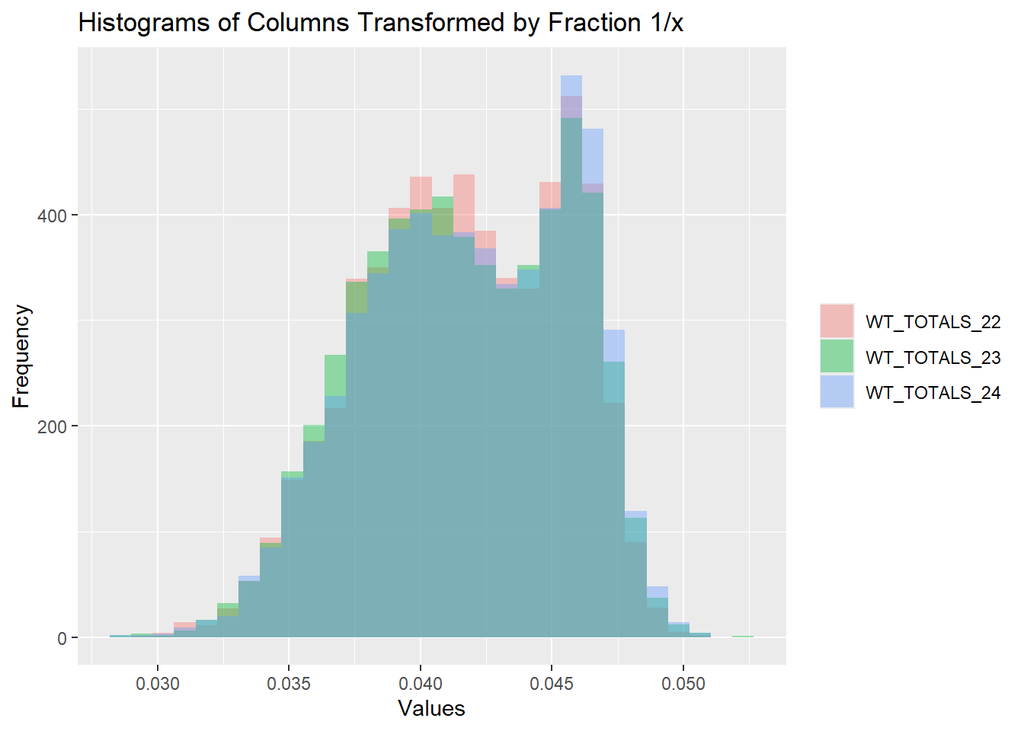

```r
LFQ_WT.frac <- 1/LFQ_WT
plothist(LFQ_WT.frac, 'Transformed by Fraction 1/x')
```

As we can see above, the results are the same like for the knockout cell type. With simple methods we can’t make the distribution closer to Gaussian dist.

## Box-Cos Transformation

The transformation is based on the formula:

$$x' = \Bigg\{
\matrix{\frac{x^{\lambda}-1}{\lambda} & \lambda \neq0 \\
log(x) & \lambda = 0}$$

```r
# At first we have to calculate the lambda
lambda.22 <- car::powerTransform(LFQ_WT$WT_TOTALS_22)$lambda
lambda.23 <- car::powerTransform(LFQ_WT$WT_TOTALS_23)$lambda
lambda.24 <- car::powerTransform(LFQ_WT$WT_TOTALS_24)$lambda
knitr::kable(data.frame(lambda.22, lambda.23, lambda.24, row.names = 'lambda'), format = 'html')
```

|  | lambda.22 | lambda.23 | lambda.24 |
| --- | --- | --- | --- |
| lambda | -2.15551 | -1.922671 | -2.313652 |

The lambda is not 0, so the first transformation is performed.

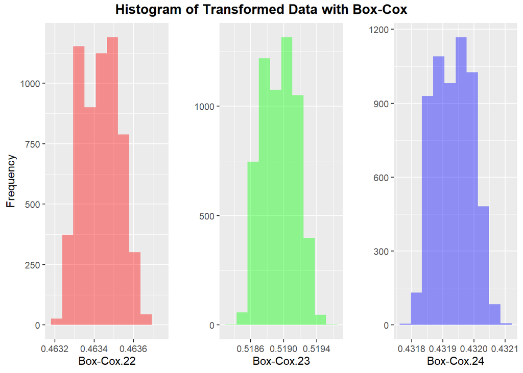

```r
LFQ_WT.boxcox.22 <- car::bcPower(LFQ_WT$WT_TOTALS_22, lambda.22)
LFQ_WT.boxcox.23 <- car::bcPower(LFQ_WT$WT_TOTALS_23, lambda.23)
LFQ_WT.boxcox.24 <- car::bcPower(LFQ_WT$WT_TOTALS_24, lambda.24)
LFQ_WT.boxcox <- data.frame(LFQ_WT.boxcox.22, LFQ_WT.boxcox.23, LFQ_WT.boxcox.24)
colnames(LFQ_WT.boxcox) <- c('WT_TOTALS_22', 'WT_TOTALS_23', 'WT_TOTALS_24')
```

```r
moments::skewness(LFQ_WT.boxcox)
```

```
## WT_TOTALS_22 WT_TOTALS_23 WT_TOTALS_24
##   0.05750385   0.05404352   0.06835686
```

And again the Box-Cox Tranformation gave us expected result. The distributions are similar to a normal distribution.

# Normalization - WT

## Z-score Normalization

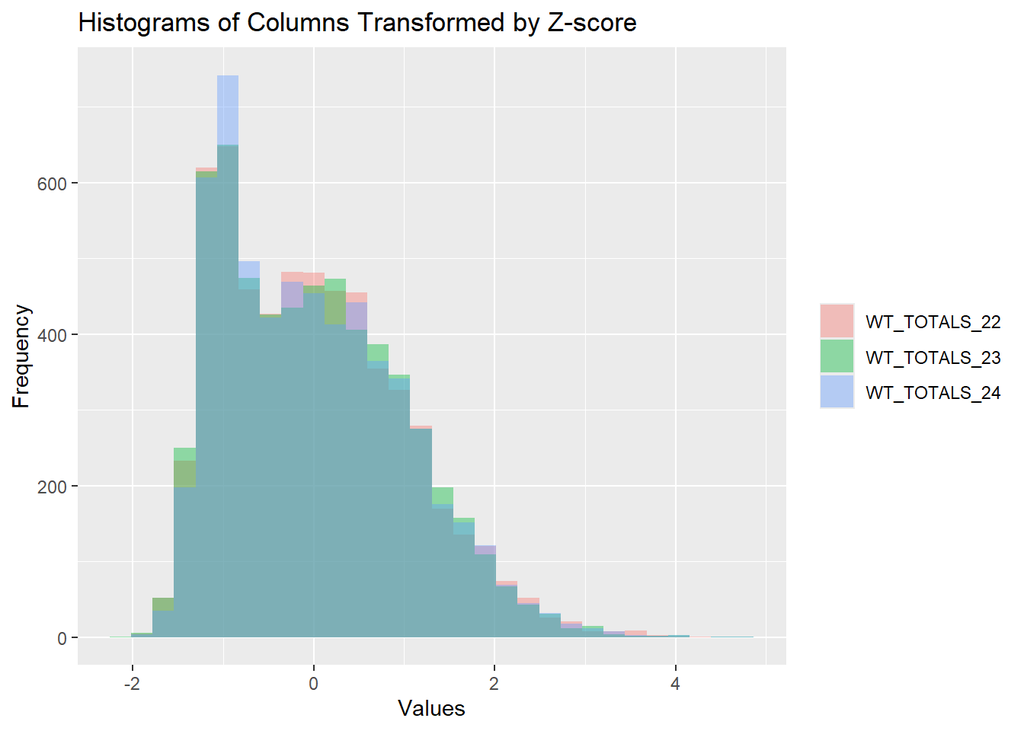

```r
LFQ_WT.standard <- as.data.frame(scale(LFQ_WT))
plothist(LFQ_WT.standard, 'Transformed by Z-score')
```

```r
moments::skewness(LFQ_KO.standard)
```

```
## KO_TOTALS_22 KO_TOTALS_23 KO_TOTALS_24
##    0.5761698    0.5868388    0.5206581
```

Unfortunately the standardization didn’t help to bring the distribution closer to the normal dist.

## Min-max Normalization

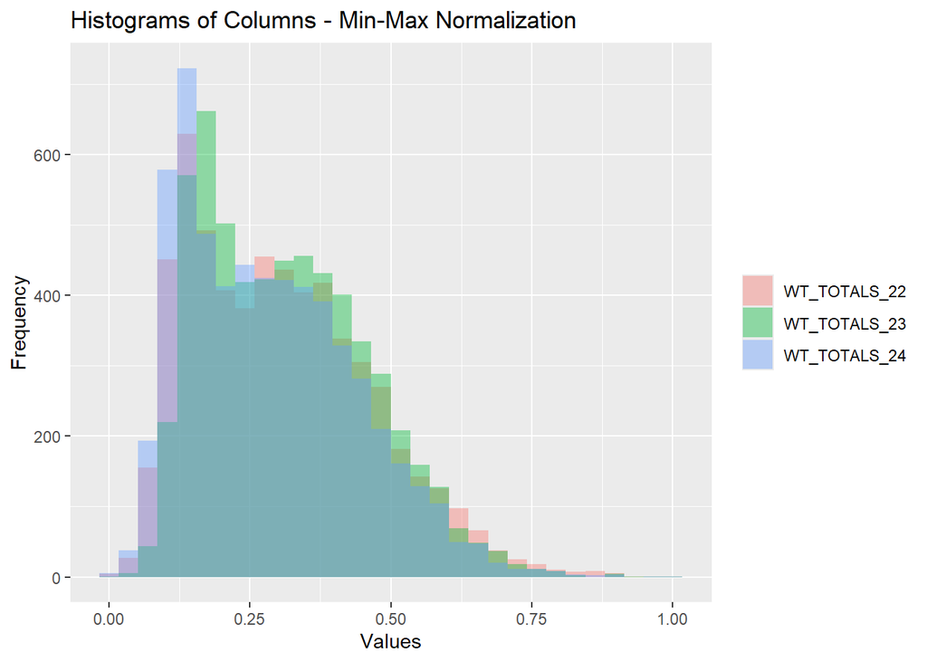

```r
min_max_norm <- function(df) {
    ret <- scale(df, center = min(df), scale = max(df) - min(df))
    return(ret)
}

LFQ_WT.minmax <- as.data.frame(lapply(LFQ_WT, function(col) min_max_norm(col)))
plothist(LFQ_WT.minmax, '- Min-Max Normalization')
```

```r
moments::skewness(LFQ_WT.minmax)
```

```
## WT_TOTALS_22 WT_TOTALS_23 WT_TOTALS_24
##    0.6285968    0.5813767    0.6579983
```

Unfortunately, again the normalization didn’t help. 😒

## Median Scaling

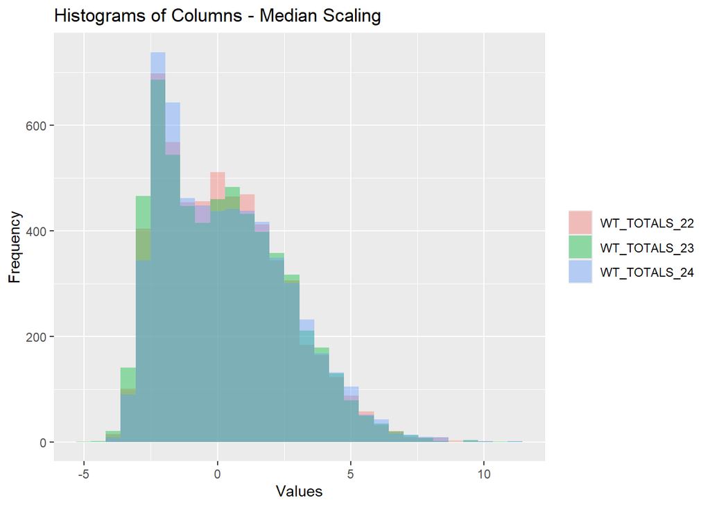

```r
LFQ_WT.med <- as.data.frame(DescTools::RobScale(LFQ_WT, scale = FALSE))
plothist(LFQ_WT.med, '- Median Scaling')
```

```r
moments::skewness(LFQ_WT.med)
```

```
## WT_TOTALS_22 WT_TOTALS_23 WT_TOTALS_24
##    0.6285968    0.5813767    0.6579983
```

## MAD Scaling

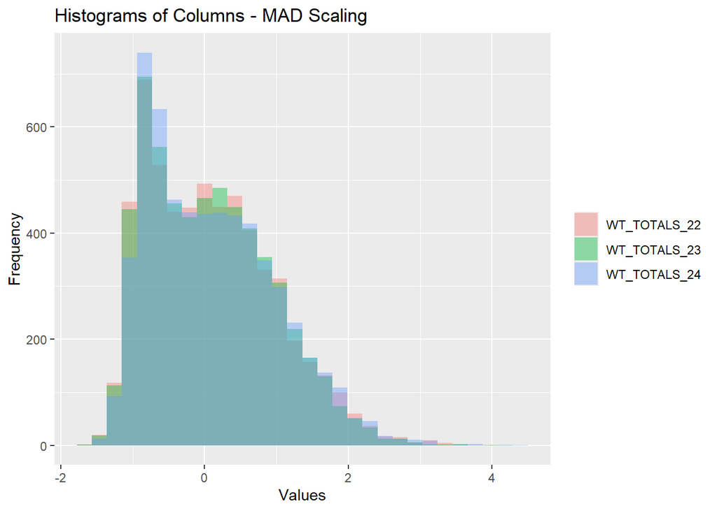

```r
LFQ_WT.mad <- as.data.frame(DescTools::RobScale(LFQ_WT))
plothist(LFQ_WT.mad, '- MAD Scaling')
```

```r
moments::skewness(LFQ_WT.mad)
```

```
## WT_TOTALS_22 WT_TOTALS_23 WT_TOTALS_24
##    0.6285968    0.5813767    0.6579983
```

## Linear Regression Normalization

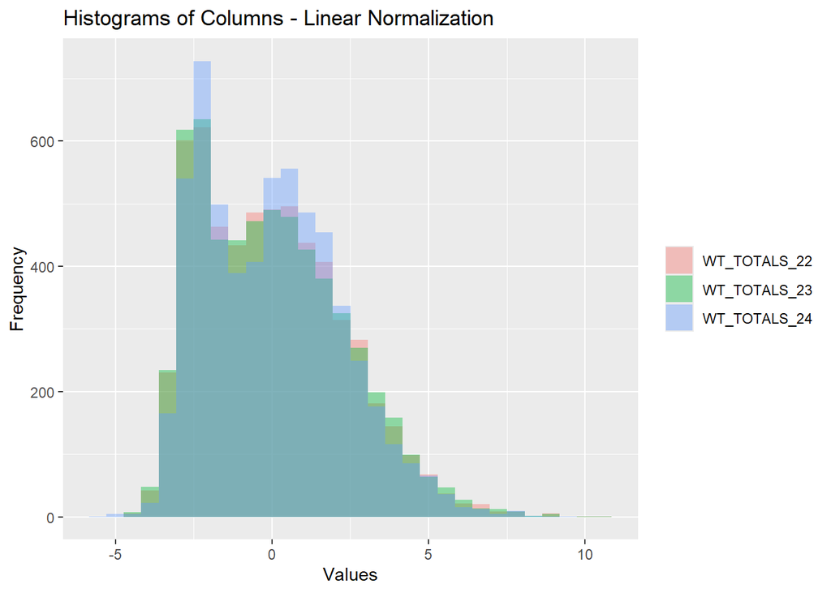

```r
LFQ_WT_long <- LFQ_WT %>%
    pivot_longer(cols = 1:3, names_to = "Rep", values_to = "LFQValue")
    #%>% mutate(celltype = rep(c(rep('WT', 3), rep('WT', 3)), nrow(lfq)))

model2 <- lm(LFQValue ~ Rep, data=LFQ_WT_long)
LFQ_WT_long$normalized <- residuals(model)

LFQ_WT.lm <- LFQ_WT_long %>%
    mutate(row = rep(1:nrow(LFQ_WT), each=3)) %>%
    reshape2::dcast(row ~ Rep, value.var='normalized') %>%
    select(-row)

plothist(LFQ_WT.lm, '- Linear Normalization')
```

```r
moments::skewness(LFQ_WT.lm)
```

```
## WT_TOTALS_22 WT_TOTALS_23 WT_TOTALS_24
##    0.5761698    0.5868388    0.5206581
```

# VSN

VSN - Variance Stabilization Normalization

```r
lfq_rglist<- new('RGList', list(
    R = as.matrix(LFQ_KO),
    G = as.matrix(LFQ_WT)))

LFQ_ALL.vsn <- justvsn(lfq_rglist)
```

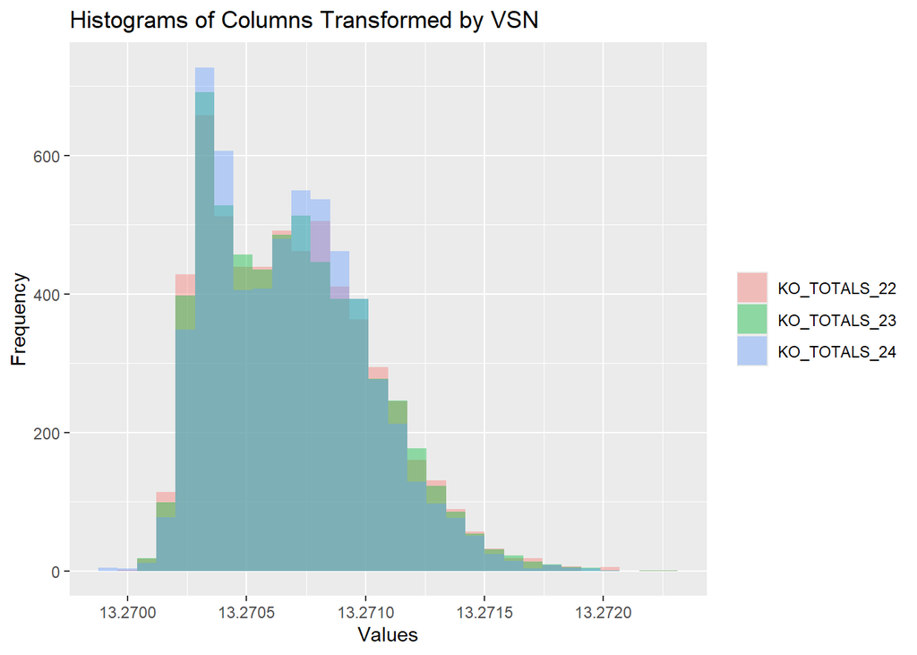

```r
plothist(LFQ_ALL.vsn@assayData[['R']], 'Transformed by VSN')
```

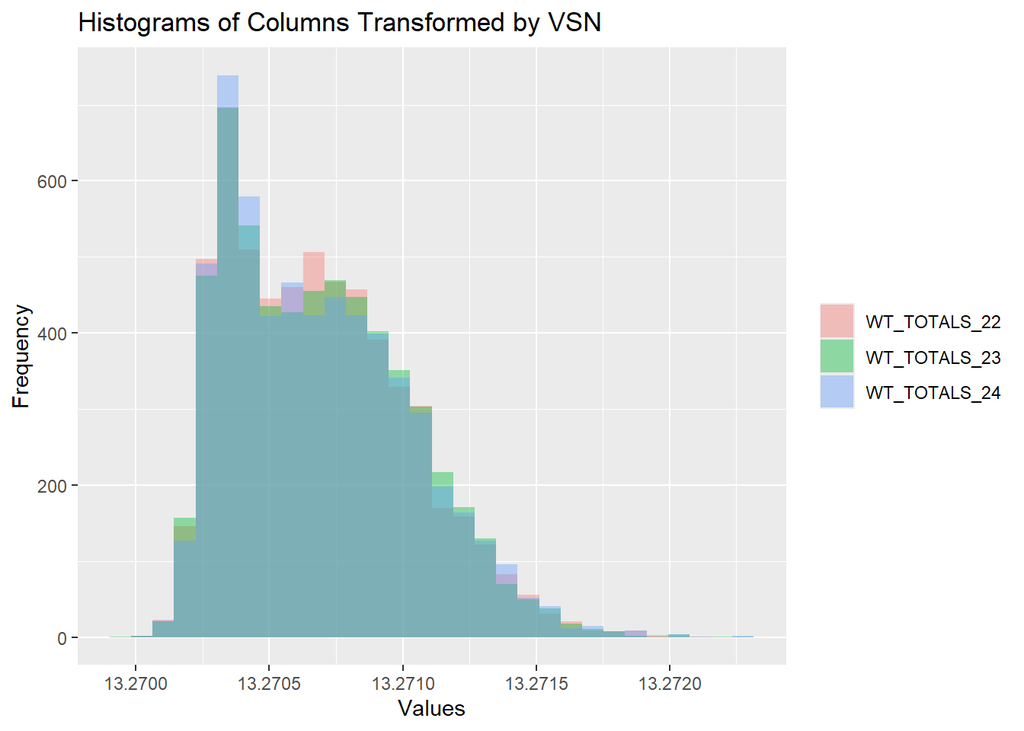

```r
plothist(LFQ_ALL.vsn@assayData[['G']], 'Transformed by VSN')
```

This transformation didn’t help us too. Furthermore we lost differences between knockout and wild type intensity.

# `bestNormalize` Package for Automatic Normalization

## KO

**Experiment 22**

```r
best.22 <- bestNormalize::bestNormalize(LFQ_KO$KO_TOTALS_22)
```

**Experiment 23**

```r
best.23 <- bestNormalize::bestNormalize(LFQ_KO$KO_TOTALS_23)
```

**Experiment 24**

```r
best.24 <- bestNormalize::bestNormalize(LFQ_KO$KO_TOTALS_24)
```

**Summary**

```
##           Exp_22    Exp_23    Exp_24
## Method orderNorm orderNorm orderNorm
```

Based on the result for each column, the best method to normalize the data is Order Quntile Normalization.

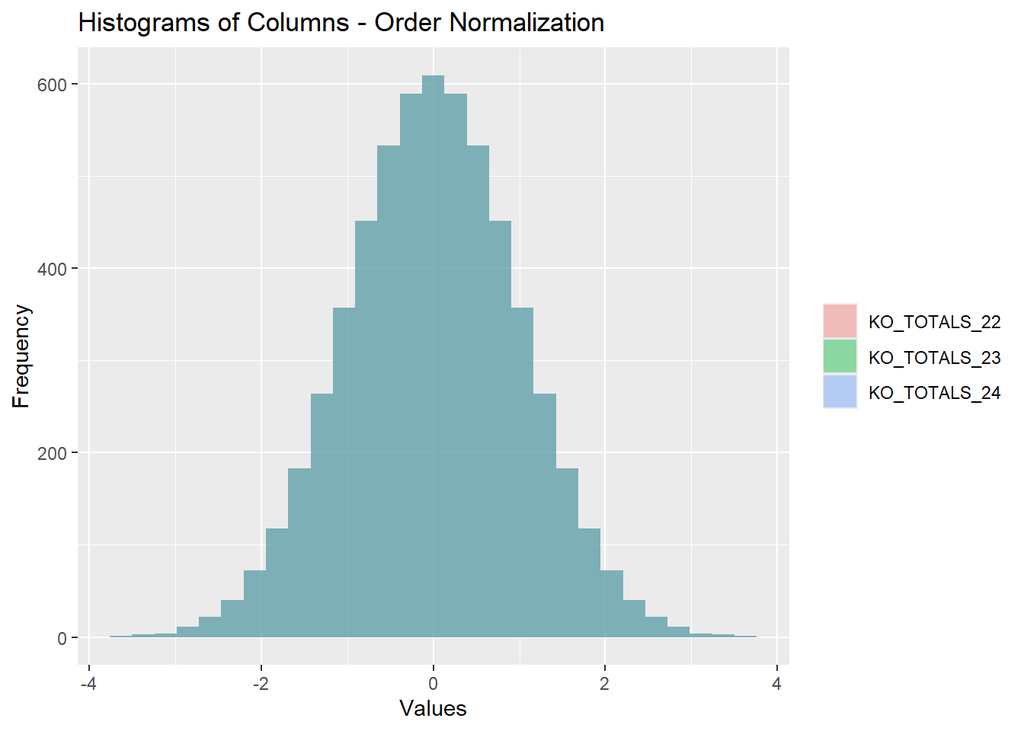

```r
LFQ_KO.ordernorm <- ordernorm(LFQ_KO)
plothist(LFQ_KO.ordernorm, '- Order Normalization')
```

## WT

**Experiment 22**

```r
best.22 <- bestNormalize::bestNormalize(LFQ_WT$WT_TOTALS_22)
```

**Experiment 23**

```r
best.23 <- bestNormalize::bestNormalize(LFQ_WT$WT_TOTALS_23)
```

**Experiment 24**

```r
best.24 <- bestNormalize::bestNormalize(LFQ_WT$WT_TOTALS_24)
```

**Summary**

```
##           Exp_22    Exp_23    Exp_24
## Method orderNorm orderNorm orderNorm
```

Like earlier the best method for each column is Order Quantile Normalization.

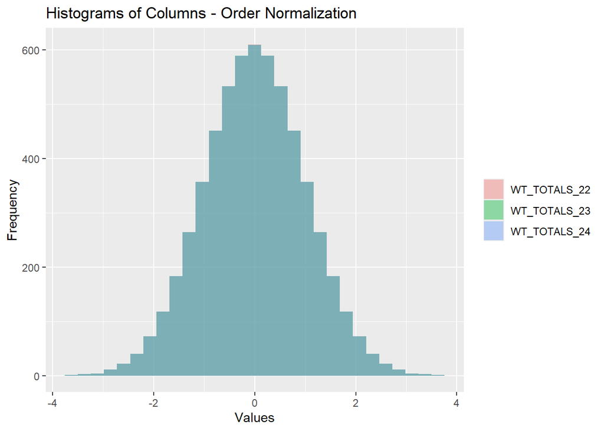

```r
LFQ_WT.ordernorm <- ordernorm(LFQ_WT)
plothist(LFQ_WT.ordernorm, '- Order Normalization')
```

# EigenMS

```r
protein.groups <- readr::read_tsv('data/proteinGroups.txt', show_col_types = FALSE)
protein.groups <- protein.groups %>% filter(is.na(`Only identified by site`),
                         is.na(Reverse),
                         is.na(`Potential contaminant`))

lfq.copy <- lfq
colnames(lfq.copy) <- c('KO.22', 'KO.23', 'KO.24', 'WT.22', 'WT.23', 'WT.24')

# I needed unique values for each peptide, so I create artificial names `prot_1:5905`
prot.info <- data.frame(protein.groups[,"Peptide sequences"], paste('prot_', 1:nrow(lfq), sep = ''))
LFQ.eig1 <- eig_norm1(lfq.copy, treatment = as.factor(c('KO', 'KO', 'KO', 'WT', 'WT', 'WT')), prot.info = prot.info)
```

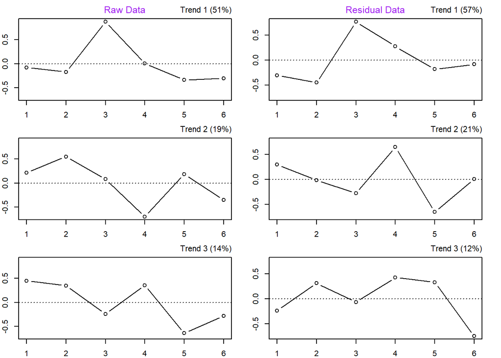

```r
# Performing eig normalization
LFQ.eig_norm <- eig_norm2(LFQ.eig1)
```

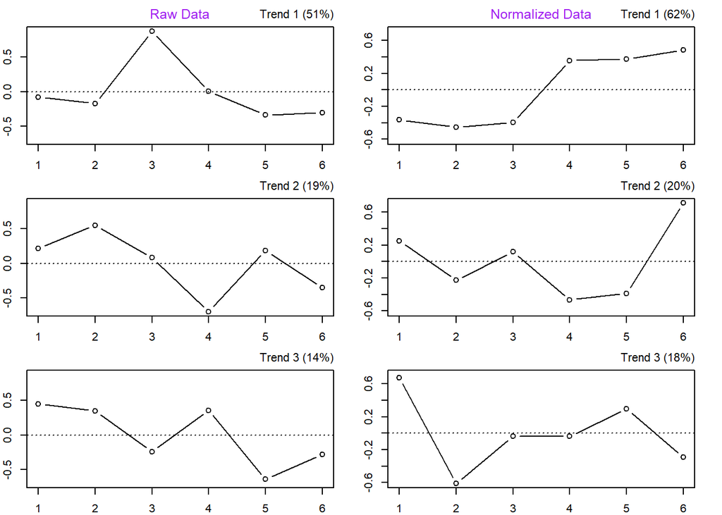

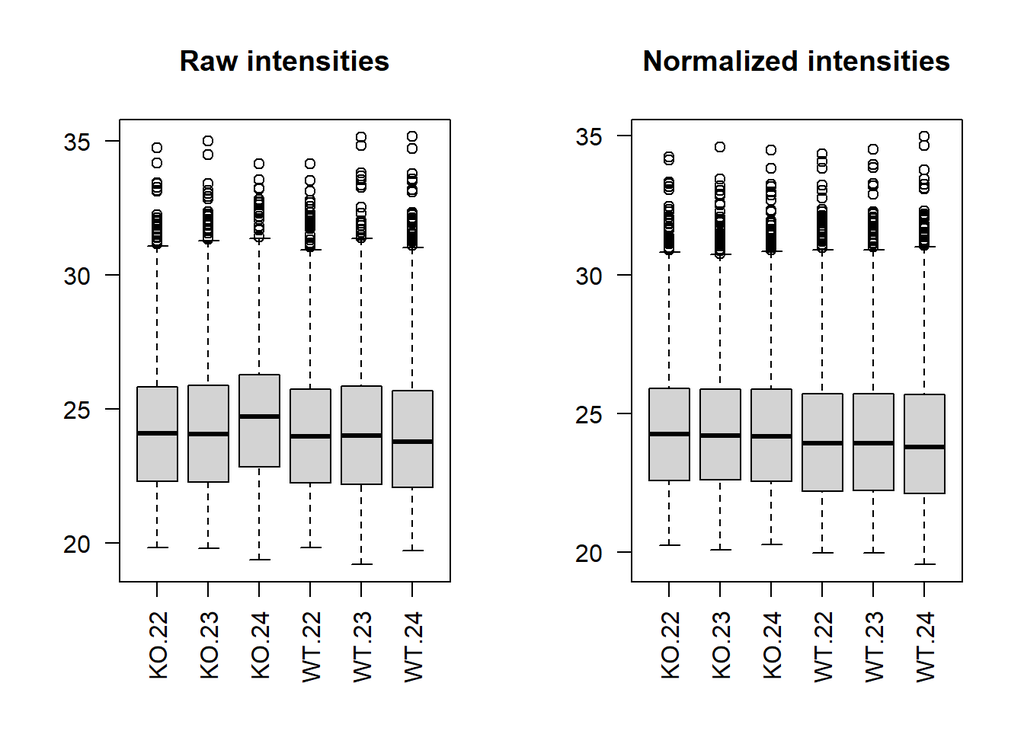

```r
par(mfcol=c(1,2))
boxplot(lfq.copy, las=2, main='Raw intensities')
boxplot(LFQ.eig_norm$norm_m, las=2, main='Normalized intensities')
```

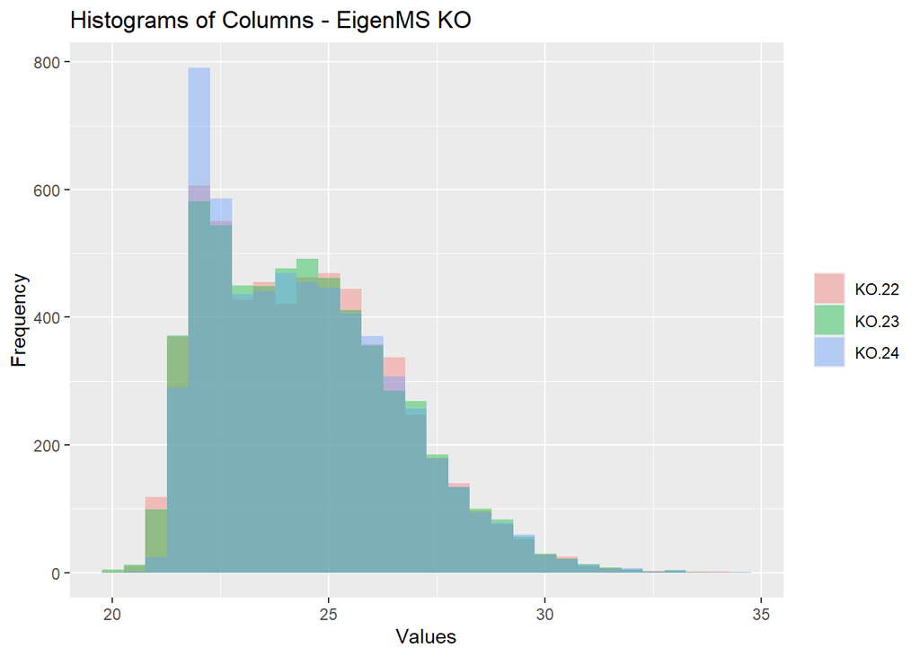

```r
plothist(LFQ.eig_norm$norm_m[,1:3], '- EigenMS KO')
```

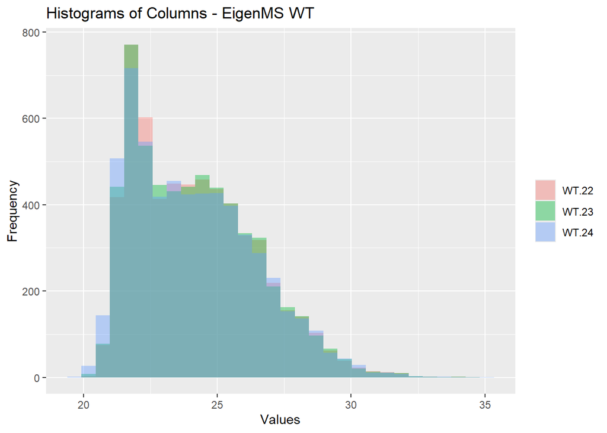

```r
plothist(LFQ.eig_norm$norm_m[,4:6], '- EigenMS WT')
```

```r
moments::skewness(LFQ.eig_norm$norm_m)
```

```
##     KO.22     KO.23     KO.24     WT.22     WT.23     WT.24
## 0.6040135 0.6322023 0.6980207 0.6800863 0.6629387 0.6618507
```

The eigen normalization perfectly shows the differences between cell type, but distributions are skewed all the time.

# Comparison

## Visualizations

**TRANSFORMATIONS**

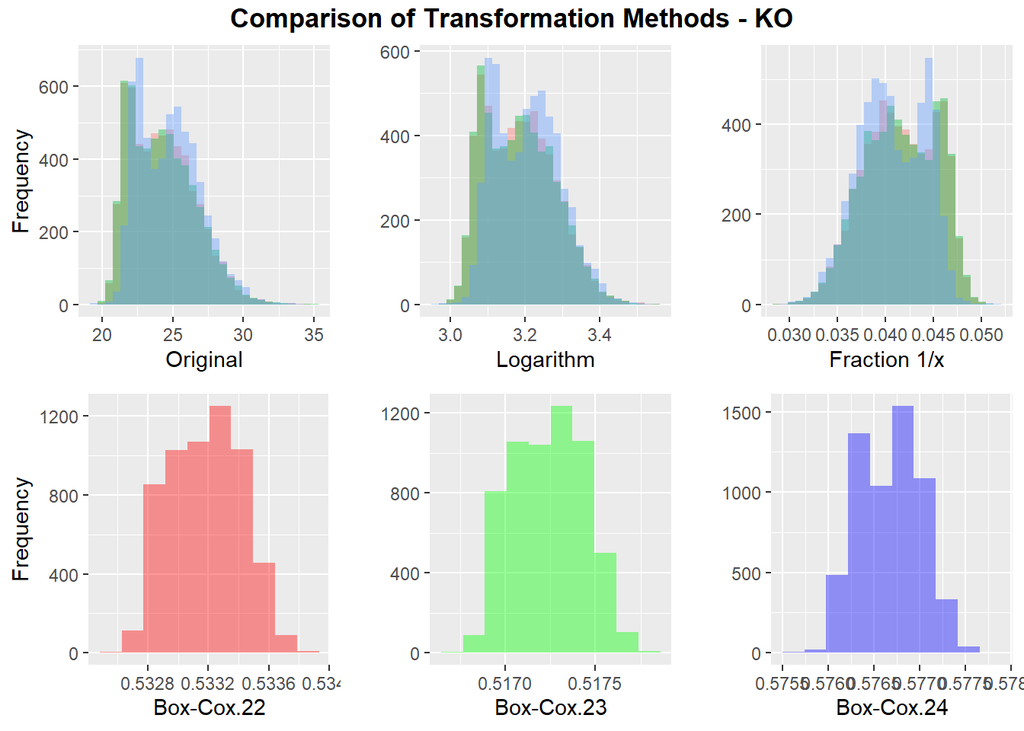

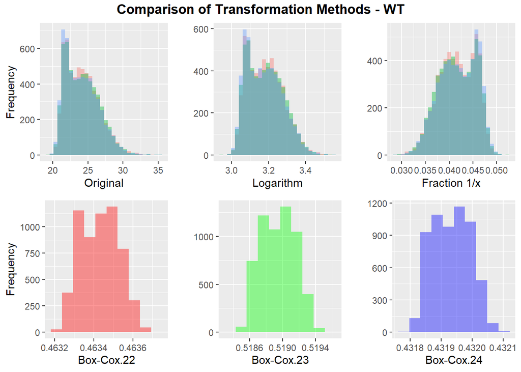

**NORMALIZATIONS**

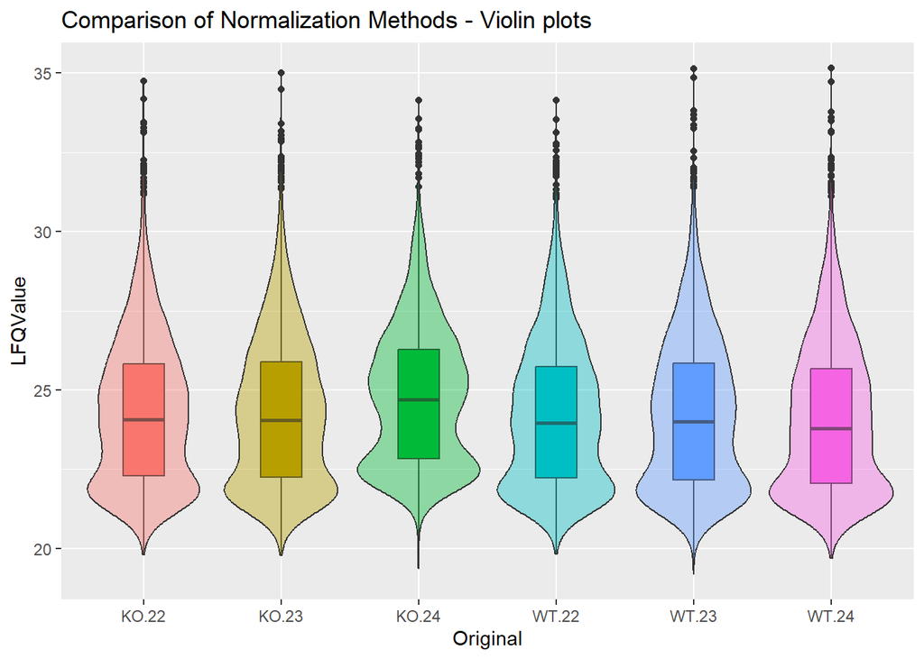